title: “Análisis de las condiciones del océano frente a Perú durante mi primer año de vida” author: “Juan Guerra” output: html_document

```r
devtools::install_github("roliveros-ramos/kali")
library(ncdf4)
library(fields)
```

```r
library(maptools)
library(ncdf4)
library(fields)
library(kali)
```

# I Introducción

Los diferentes procesos biológicos y ecológicos en el océano, son determinados por varios drivers ambientales en diferente escala espacio temporal (Haury, et. al., 1978). Por ejemplo la temperatura superficial del mar, la salinidad, los vientos afectan directa e indirectamente la productividad primaria, y la distribución espacial de diferentes especies u organismos. Los organismos presentan rangos óptimos y no óptimos de su presencia en función de las variables ambientales, “llamada Ventana ambiental” siendo necesario el entendimiento de dicha relación (Cury and Roy, 1989). Se justifica entonces la necesidad de caracterizar el ambiente, por lo que el objetivo del presente estudio es caracterizar y analizar la temperatura superficial del mar, la salinidad y la productividad media dusrante los ultimo 50 años, y su relacion con el año 1988, como punto de partida para entender la variación espacial anual, estacional de la productividad, mediante un proxy que es la concentración de fitoplancton, productividad primaria que sostiene a las pesquerías importantes(Pennington, et. Al., 2006)

# II Materiales y métodos

## 2.1 Materiales

### 2.1.1 Variables Ambientales

Las variables para el análisis de las condiciones oceanográficas, que incluye datos de temperatura superficial del mar (sst), salinidad superficial del mar (sss) proporcionada del archivo netCDF Network Common Data Form a partir de Unidata que es parte de la Corporación Universitaria para la Investigación Atmosférica (UCAR).

```r
nc1 = nc_open("datos/sst.nc4")
nc2 = nc_open("datos/sss.nc4")
```

### 2.1.2 Variables Bióticas

Como proxy de productividad y distribución de los organismos se tomara las variables espacial del fitoplancton pequeño(sphy) y grande(lphy), Teniendo la misma fuente de datos, y el mismo formato que los datos ambientales. siendo las variables las siguientes:

Large phyto. production vertical integral(lphy) en molCm-2s-1

Small phyto. production vertical integral(sphy) en molCm-2s-1

```r
nc3 = nc_open("datos/lphy.nc4")
nc4 = nc_open("datos/sphy.nc4")
```

## 2.2 Métodos

### 2.2.1 Paquetes y Software

Para la realización de los análisis se usó el paquete estadístico R y los paquetes de R: markdown, kali, ncdf4 y fields. Para el análisis interactivo de texto, utilización de mapas y gráficas.

### 2.2.2 Análisis exploratorio de las Variables:

• Se realizaron comparaciones entre los promedios totales de las variables y las anomalias. Las anomalias se definieron como: Anomalias=Promedio(todos los años)-Promedio(año 1988).

# III Resultados y discusión

### Temperatura promedio, minimos, maximos y desviacion estandar

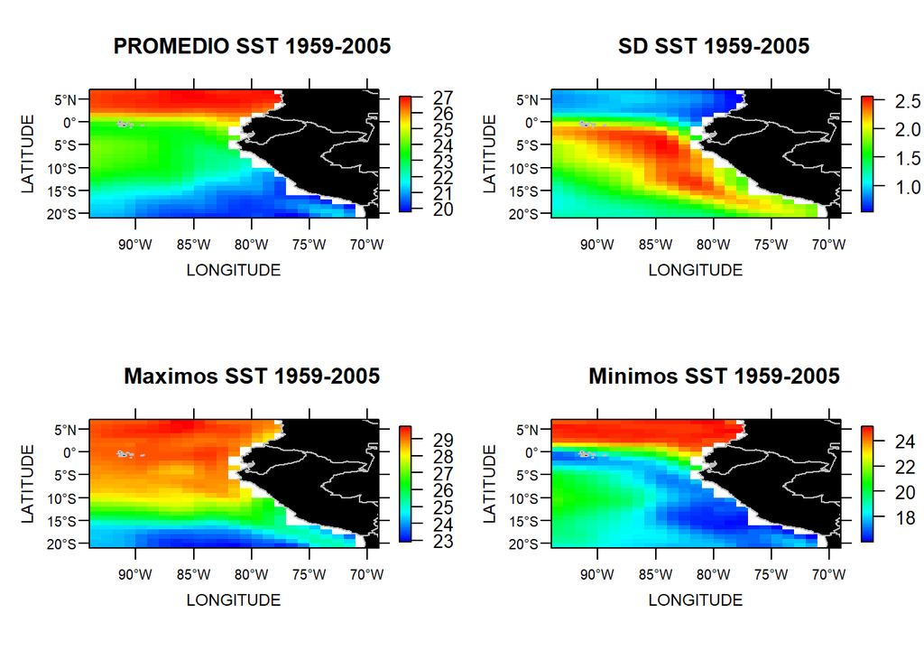

```r
#variable sst
nc_sst=nc_open("datos/sst.nc4")
sst = ncvar_get(nc_sst, "to")
lat = ncvar_get(nc_sst, "latitude")
lon = ncvar_get(nc_sst, "longitude") - 360

#Grafico promedio, minimos y maximos de SST

par(mfrow=c(2,2))

sst_promedio=apply(sst[,,1:552], MARGIN = c(1,2), FUN=mean, na.rm = TRUE)
image.map(lon, lat, sst_promedio)
title("PROMEDIO SST 1959-2005")

sst_sd=apply(sst[,,1:552], MARGIN = c(1,2), FUN=sd, na.rm = TRUE)
image.map(lon, lat, sst_sd)
title("SD SST 1959-2005")

sst_max=apply(sst[,,1:552], MARGIN = c(1,2), FUN=max, na.rm = FALSE)
image.map(lon, lat, sst_max)
title("Maximos SST 1959-2005")

sst_min=apply(sst[,,1:552], MARGIN = c(1,2), FUN=min, na.rm = FALSE)
image.map(lon, lat, sst_min)
title("Minimos SST 1959-2005")
```

### Estimacion de la Anomalia para el Año de 1988 respecto a la media

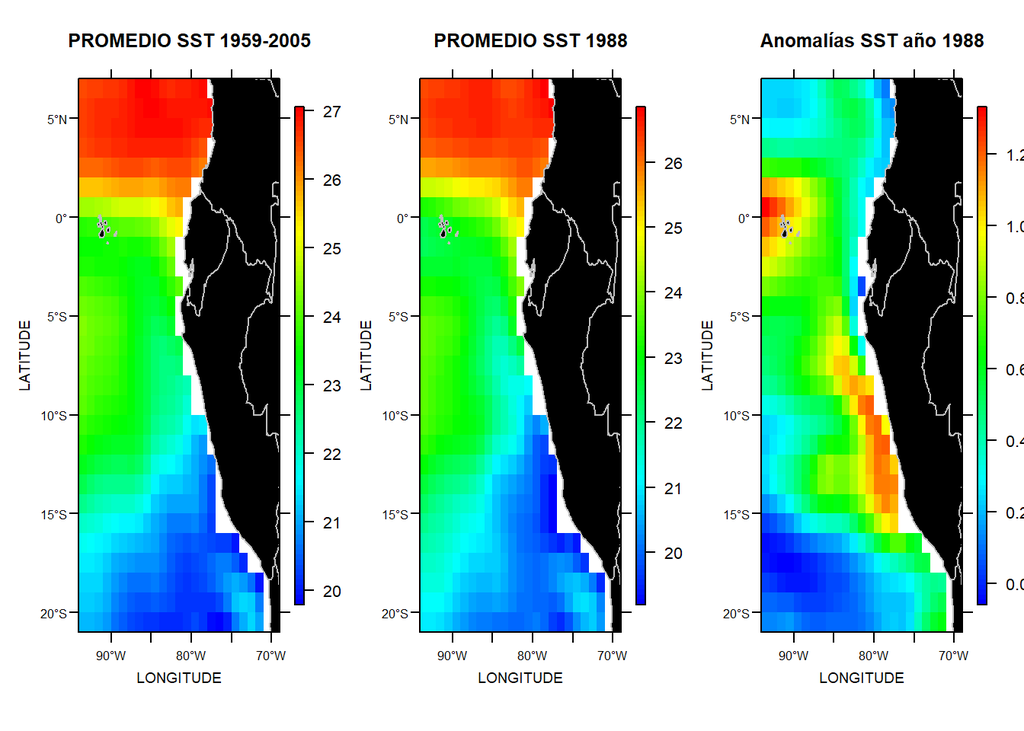

```r
sst_1988=apply(sst[,,349:360], MARGIN = c(1,2), FUN = mean, na.rm = TRUE)
anomalia_sst=sst_promedio-sst_1988

#Grafico Anomalias de año 1988, respecto a al  promedio.

par(mfrow=c(1,3))
image.map(lon, lat, sst_promedio)
title("PROMEDIO SST 1959-2005")

image.map(lon, lat, sst_1988)
title("PROMEDIO SST 1988")

image.map(lon, lat, anomalia_sst)
title("Anomalías SST año 1988")
```

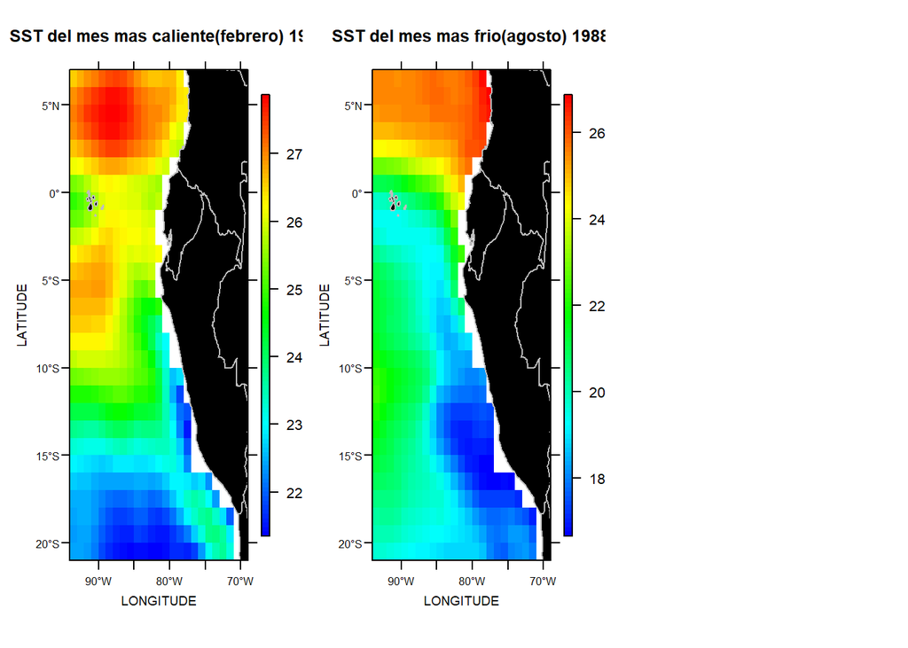

```r
image.map(lon, lat, sst[,,350])
title("SST del mes mas caliente(febrero) 1988")

image.map(lon, lat, sst[,,356])
title("SST del mes mas frio(agosto) 1988")
```

### Salinidad promedio, minimos, maximos y desviacion estandar

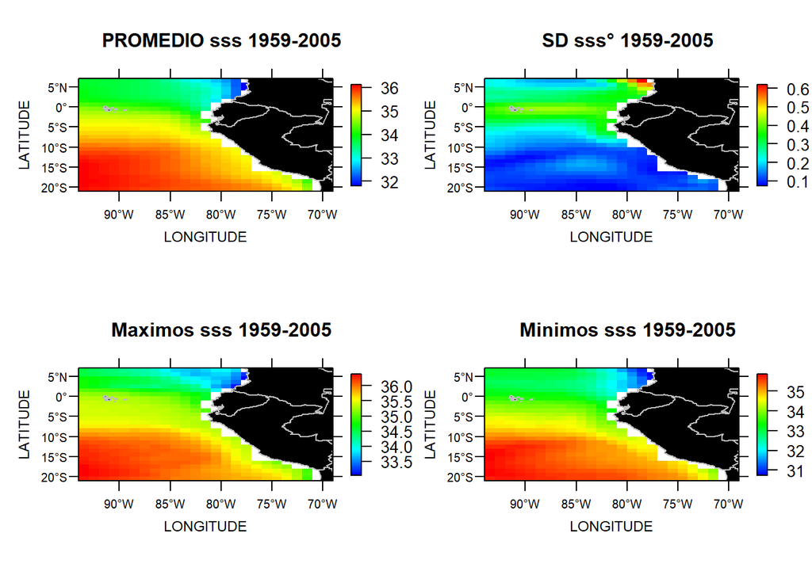

```r
#variable sss
nc_sss=nc_open("datos/sss.nc4")
sss = ncvar_get(nc_sss, "so")
lat = ncvar_get(nc_sss, "latitude")
lon = ncvar_get(nc_sss, "longitude") - 360

#Grafico promedio, minimos y maximos de sss

par(mfrow=c(2,2))

sss_promedio=apply(sss[,,1:552], MARGIN = c(1,2), FUN=mean, na.rm = TRUE)
image.map(lon, lat, sss_promedio)
title("PROMEDIO sss 1959-2005")

sss_sd=apply(sss[,,1:552], MARGIN = c(1,2), FUN=sd, na.rm = TRUE)
image.map(lon, lat, sss_sd)
title("SD sss° 1959-2005")

sss_max=apply(sss[,,1:552], MARGIN = c(1,2), FUN=max, na.rm = FALSE)
image.map(lon, lat, sss_max)
title("Maximos sss 1959-2005")

sss_min=apply(sss[,,1:552], MARGIN = c(1,2), FUN=min, na.rm = FALSE)
image.map(lon, lat, sss_min)
title("Minimos sss 1959-2005")
```

### Estimacion de la Anomalia para el Año de 1988 respecto a la media

```r
sss_1988=apply(sss[,,349:360], MARGIN = c(1,2), FUN = mean, na.rm = TRUE)
anomalia_sss=sss_promedio-sss_1988
```

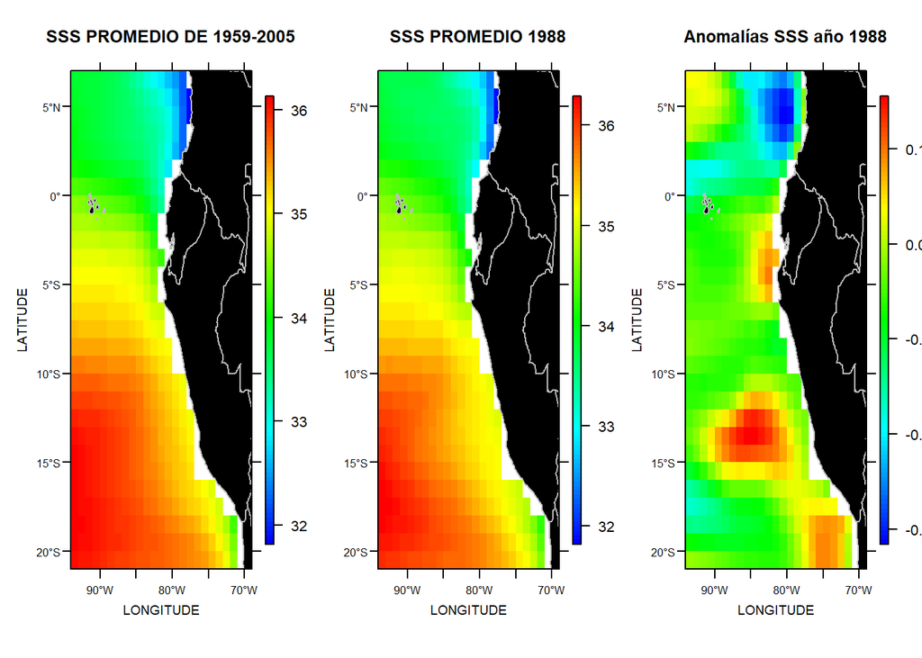

```r
#Grafico Anomalias de año 1988, respecto a al  promedio.

par(mfrow=c(1,3))
image.map(lon, lat, sss_promedio)
title("SSS PROMEDIO DE 1959-2005")

image.map(lon, lat, sss_1988)
title("SSS PROMEDIO 1988")

image.map(lon, lat, anomalia_sss)
title("Anomalías SSS año 1988")
```

### Varibilidad espacial de la productividad(fitoplancton grande)

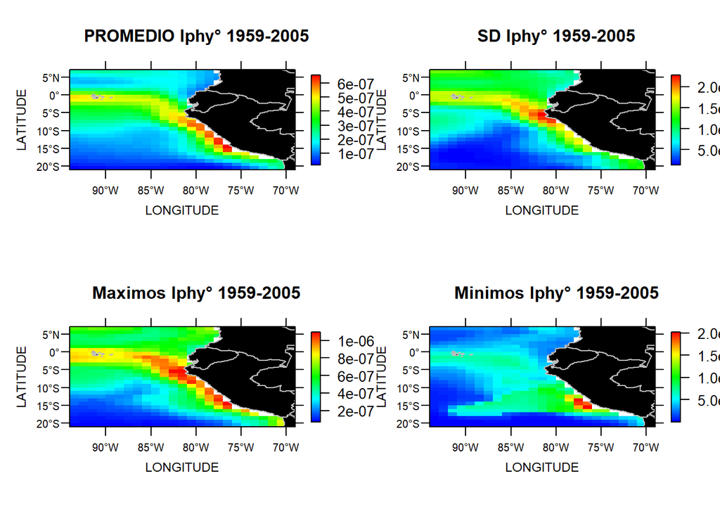

```r
#variable lphy
nc_lphy=nc_open("datos/lphy.nc4")
lphy = ncvar_get(nc_lphy, "intpp")
lat = ncvar_get(nc_lphy, "latitude")
lon = ncvar_get(nc_lphy, "longitude") - 360

#Grafico promedio, minimos y maximos de lphy

par(mfrow=c(2,2))

lphy_promedio=apply(lphy[,,1:552], MARGIN = c(1,2), FUN=mean, na.rm = TRUE)
image.map(lon, lat, lphy_promedio)
title("PROMEDIO lphy° 1959-2005")

lphy_sd=apply(lphy[,,1:552], MARGIN = c(1,2), FUN=sd, na.rm = TRUE)
image.map(lon, lat, lphy_sd)
title("SD lphy° 1959-2005")

lphy_max=apply(lphy[,,1:552], MARGIN = c(1,2), FUN=max, na.rm = FALSE)
image.map(lon, lat, lphy_max)
title("Maximos lphy° 1959-2005")

lphy_min=apply(lphy[,,1:552], MARGIN = c(1,2), FUN=min, na.rm = FALSE)
image.map(lon, lat, lphy_min)
title("Minimos lphy° 1959-2005")
```

### Estimacion de la Anomalia para el Año de 1988 respecto a la media

```r
lphy_1988=apply(lphy[,,349:360], MARGIN = c(1,2), FUN = mean, na.rm = TRUE)
anomalia_lphy=lphy_promedio-lphy_1988
```

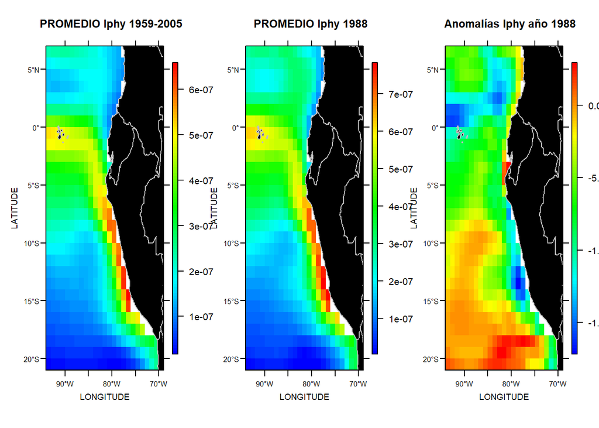

```r
#Grafico Anomalias de año 1988, respecto a al  promedio.

par(mfrow=c(1,3))
image.map(lon, lat, lphy_promedio)
title("PROMEDIO lphy 1959-2005")

image.map(lon, lat, lphy_1988)
title("PROMEDIO lphy 1988")

image.map(lon, lat, anomalia_lphy)
title("Anomalías lphy año 1988")
```

### Varibilidad espacial de la productividad(fitoplancton pequeño)

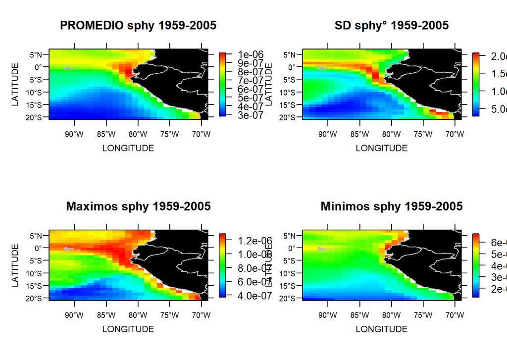

```r
#variable sphy
nc_sphy=nc_open("datos/sphy.nc4")
sphy = ncvar_get(nc_sphy, "intpp")
lat = ncvar_get(nc_sphy, "latitude")
lon = ncvar_get(nc_sphy, "longitude") - 360

#Grafico promedio, minimos y maximos de sphy

par(mfrow=c(2,2))

sphy_promedio=apply(sphy[,,1:552], MARGIN = c(1,2), FUN=mean, na.rm = TRUE)
image.map(lon, lat, sphy_promedio)
title("PROMEDIO sphy 1959-2005")

sphy_sd=apply(sphy[,,1:552], MARGIN = c(1,2), FUN=sd, na.rm = TRUE)
image.map(lon, lat, sphy_sd)
title("SD sphy° 1959-2005")

sphy_max=apply(sphy[,,1:552], MARGIN = c(1,2), FUN=max, na.rm = FALSE)
image.map(lon, lat, sphy_max)
title("Maximos sphy 1959-2005")

sphy_min=apply(sphy[,,1:552], MARGIN = c(1,2), FUN=min, na.rm = FALSE)
image.map(lon, lat, sphy_min)
title("Minimos sphy 1959-2005")
```

### Estimacion de la Anomalia para el Año de 1988 respecto a la media

```r
sphy_1988=apply(sphy[,,349:360], MARGIN = c(1,2), FUN = mean, na.rm = TRUE)
anomalia_sphy=sphy_promedio-sphy_1988
```

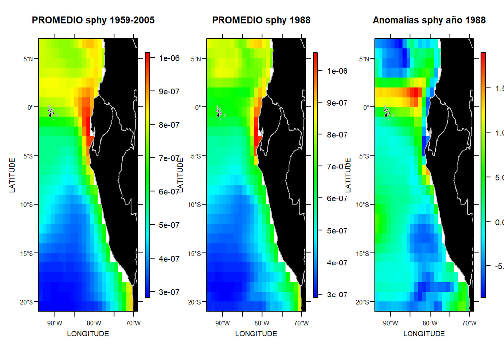

```r
#Grafico Anomalias de año 1988, respecto a al  promedio.

par(mfrow=c(1,3))
image.map(lon, lat, sphy_promedio)
title("PROMEDIO sphy 1959-2005")

image.map(lon, lat, sphy_1988)
title("PROMEDIO sphy 1988")

image.map(lon, lat, anomalia_sphy)
title("Anomalías sphy año 1988")
```

Sintesis final Anomalias

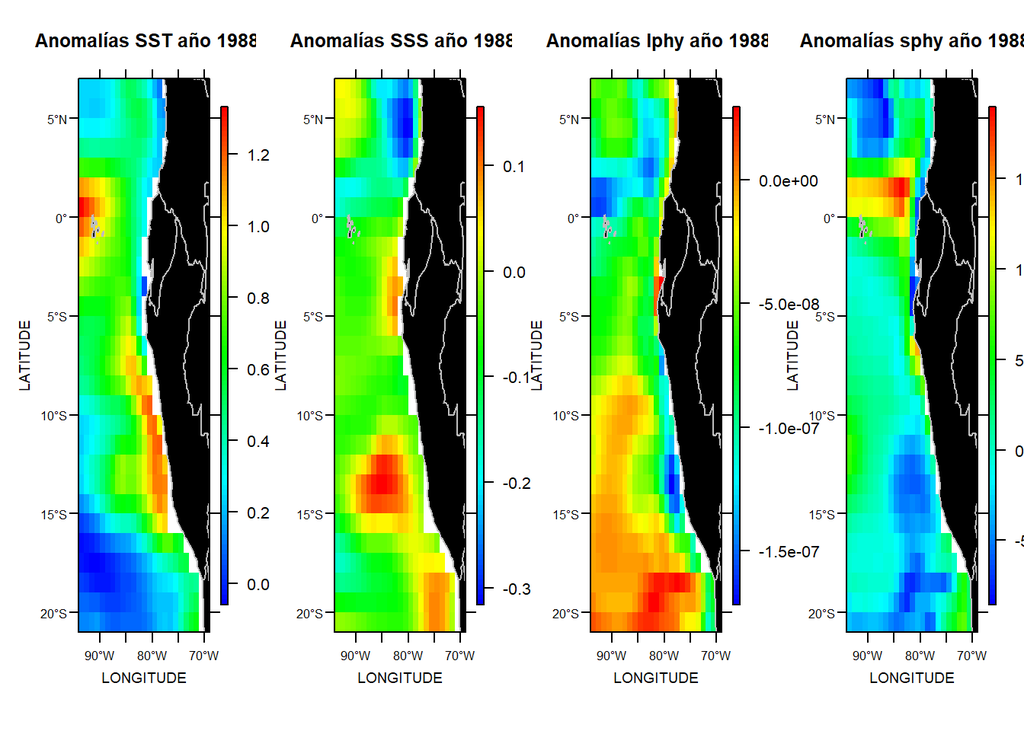

```r
par(mfrow=c(1,4))

image.map(lon, lat, anomalia_sst)
title("Anomalías SST año 1988")

image.map(lon, lat, anomalia_sss)
title("Anomalías SSS año 1988")

image.map(lon, lat, anomalia_lphy)
title("Anomalías lphy año 1988")

image.map(lon, lat, anomalia_sphy)
title("Anomalías sphy año 1988")
```

Sintesis final de los valores medios de todas las variables

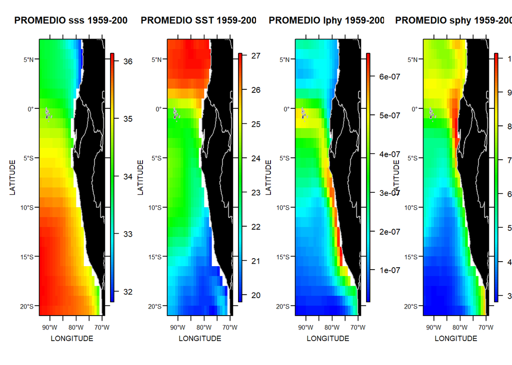

```r
par(mfrow=c(1,4))

image.map(lon, lat, sss_promedio)
title("PROMEDIO sss 1959-2005")

image.map(lon, lat, sst_promedio)
title("PROMEDIO SST 1959-2005")

image.map(lon, lat, lphy_promedio)
title("PROMEDIO lphy 1959-2005")

image.map(lon, lat, sphy_promedio)
title("PROMEDIO sphy 1959-2005")
```

# IV Conclusiones

La mayor productividad se presenta en la zona centro norte del pais, donde existe un aumento de la temperaturaa, respecto al sur.

Los promedios de las variables ambientales y productividad de los ultimos 50 años descritas en el presente estudio, tienen la misma tendencia que las año 1988.

# V Referencias Bibliograficas

#### • UNIDATA, Data services and tolos for geoscience, Fuente de datos en formato NETCDF, extraído de https://www.unidata.ucar.edu/software/netcdf/.

#### • PENNINGTON, J.T.et. al. 2006. Primary production in the eastern tropical Pacific: A review. Prog. Oceanogr. 69, 285–317.

#### • HAURY, L. R., J. A. MCGOWAN, AND P. H. WIEBE. 1978. Patterns and processes in the time-space scales of plankton distribution, p. 277-327. EnJ. H. Steele [ed.], Spatial patterns in plankton communities.

#### • CURY, P. & C. ROY. 1989. Optimal environmental window and pelagic fish recruitment sucessin upwelling areas. Can. J. Fish. Aquat. Sci., 46:670-680.